# Reproducible Research project 1

NH Forensic

24/07/2020

## Loading and preprocessing the data

```r
data <- read.csv("activity.csv")
data$date <- as.Date(data$date)
```

## What is mean total number of steps taken per day?

### 1) Calculate the total number of steps taken per day

```r
dailysum <- aggregate(steps ~ date,
                      data = data,
                      FUN = sum,
                      na.rm = TRUE)
dailysum
```

```
##          date steps
## 1  2012-10-02   126
## 2  2012-10-03 11352
## 3  2012-10-04 12116
## 4  2012-10-05 13294
## 5  2012-10-06 15420
## 6  2012-10-07 11015
## 7  2012-10-09 12811
## 8  2012-10-10  9900
## 9  2012-10-11 10304
## 10 2012-10-12 17382
## 11 2012-10-13 12426
## 12 2012-10-14 15098
## 13 2012-10-15 10139
## 14 2012-10-16 15084
```

[output cut: 39 more lines]

### 2) Make a histogram of the total number of steps taken each day

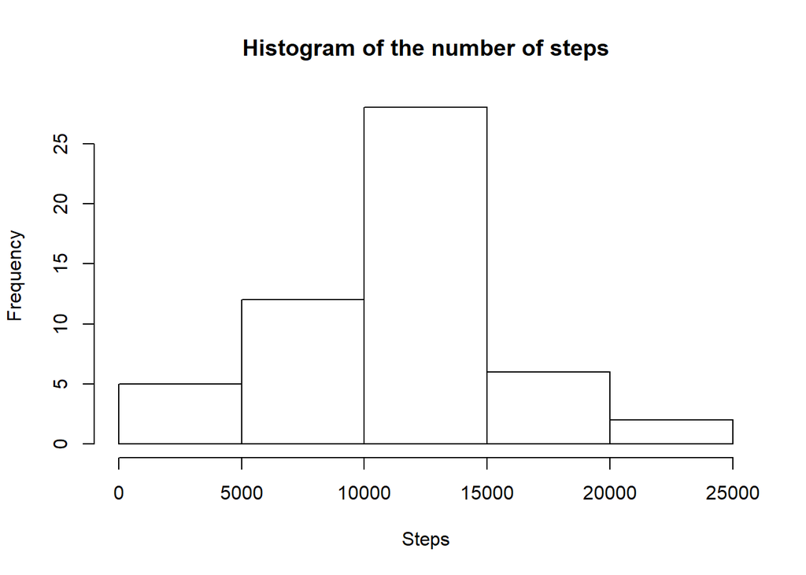

```r
hist(dailysum$steps, xlab = "Steps", main = "Histogram of the number of steps")
```

```r
meansteps <- mean(dailysum$steps)
```

```r
mediansteps <- median(dailysum$steps)
```

Median of the total number of steps taken per day = 10765.

## What is the average daily activity pattern?

```r
meandailyactivity <- aggregate(steps ~ interval,
                               data = data,
                               FUN = mean,
                               na.rm = TRUE)
```

### 1) Make a time series plot (i.e. type = “l”) of the 5-minute interval (x-axis) and the average number of steps taken, averaged across all days (y-axis)

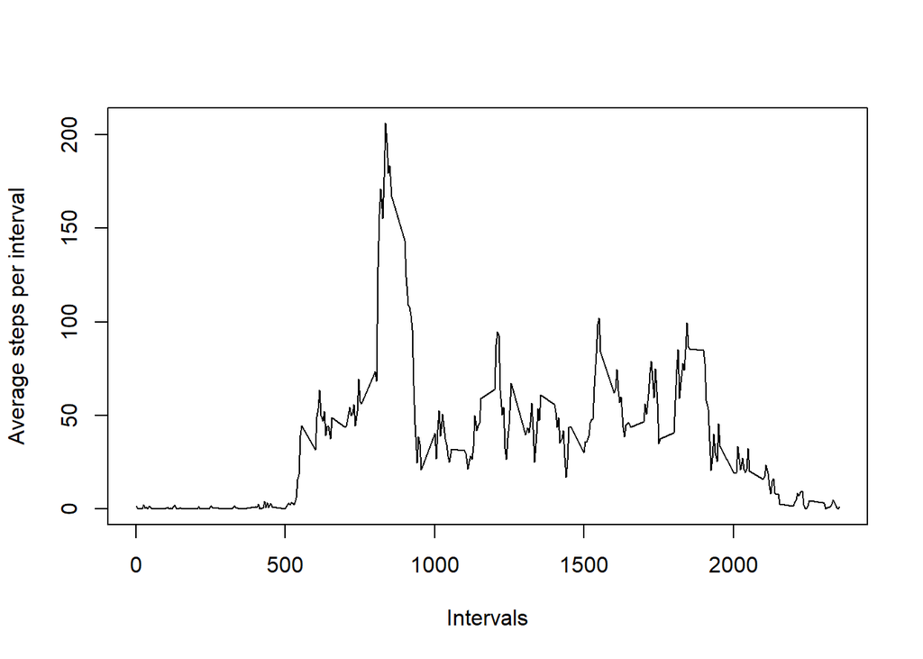

```r
plot(meandailyactivity$interval, meandailyactivity$steps,
     type = "l",
     xlab = "Intervals",
     ylab = "Average steps per interval")
```

### 2) Which 5-minute interval, on average across all the days in the dataset, contains the maximum number of steps?

```r
maxsteps <- max(meandailyactivity$steps)
maxinterval <- meandailyactivity$interval[
    which(meandailyactivity$steps == maxsteps)]

maxinterval
```

```
## [1] 835
```

## Imputing missing values

### 1) Calculate and report the total number of missing values in the dataset (i.e. the total number of rows with NAs)

```r
sum(is.na(data$steps))
```

```
## [1] 2304
```

### 2) Devise a strategy for filling in all of the missing values in the dataset. Create a new dataset that is equal to the original dataset but with the missing data filled in.

```r
intervalmean <- tapply(data$steps, data$interval, mean, na.rm = TRUE)

stepsNAs <- data[is.na(data$steps),]
stepswithdata <- data[!is.na(data$steps),]

stepsNAs$steps <- as.factor(stepsNAs$interval)
levels(stepsNAs$steps) <- intervalmean

stepsNAs$steps <- as.numeric(stepsNAs$steps)

newdata <- rbind(stepsNAs, stepswithdata)
```

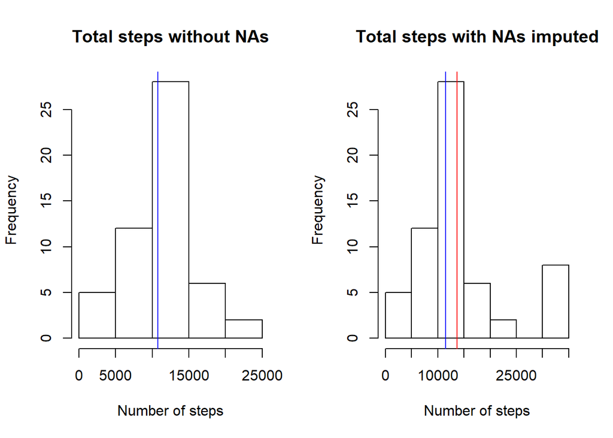

```r
par(mfrow = c(1, 2))

hist(dailysum$steps,
     main = "Total steps without NAs",
     xlab = "Number of steps")
abline(v = mean(dailysum$steps), col = "red")
abline(v = median(dailysum$steps), col = "blue")

newdailysum <- aggregate(steps ~ date,
                      data = newdata,
                      FUN = sum)

hist(newdailysum$steps,
     main = "Total steps with NAs imputed",
     xlab = "Number of steps")
abline(v = mean(newdailysum$steps), col = "red")
abline(v = median(newdailysum$steps), col = "blue")
```

```r
newmean <- mean(newdailysum$steps)
```

```r
newmedian <- median(newdailysum$steps)
```

## Are there differences in activity patterns between weekdays and weekends?

### 1) Create a new factor variable in the dataset with two levels – “weekday” and “weekend” indicating whether a given date is a weekday or weekend day.

```r
newdata$weekday <- weekdays(newdata$date)
newdata$wkendorwkday <- ifelse(newdata$weekday == "Sunday"
                               | newdata$weekday == "Saturday", "Weekend", "Weekday")
```

### 2) Make a panel plot containing a time series plot (i.e. type = “l”) of the 5-minute interval (x-axis) and the average number of steps taken, averaged across all weekday days or weekend days (y-axis).

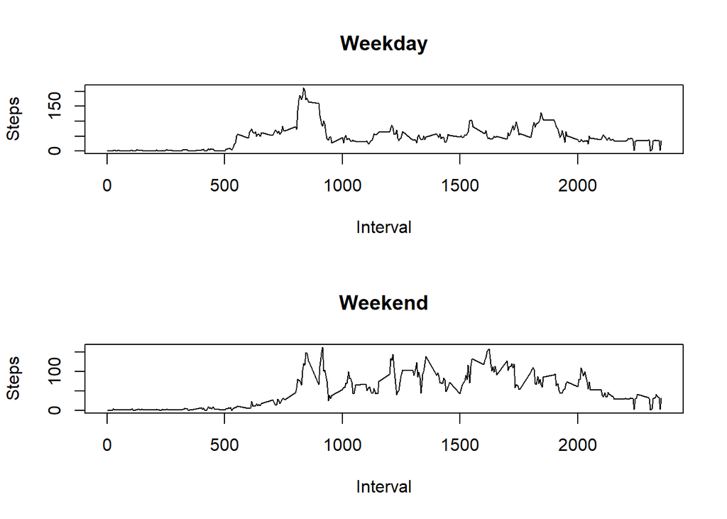

```r
weekdaydata <- subset(newdata, wkendorwkday == "Weekday")
weekenddata <- subset(newdata, wkendorwkday == "Weekend")

weekdayagg <- aggregate(steps ~ interval, data = weekdaydata, FUN = mean)
weekendagg <- aggregate(steps ~ interval, data = weekenddata, FUN = mean)

par(mfrow = c(2, 1))
plot(weekdayagg$interval, weekdayagg$steps,
     type = "l",
     xlab = "Interval",
     ylab = "Steps",
     main = "Weekday")
plot(weekendagg$interval, weekendagg$steps,
     type = "l",
     xlab = "Interval",
     ylab = "Steps",
     main = "Weekend")
```